# R Notebook

**Principles of Data Visualization and Introduction to ggplot2**

I have provided you with data about the 5,000 fastest growing companies in the US, as compiled by Inc. magazine. lets read this in:

```r
inc <- read.csv("https://raw.githubusercontent.com/charleyferrari/CUNY_DATA_608/master/module1/Data/inc5000_data.csv", header= TRUE)
```

And lets preview this data:

```r
head(inc)
```

```
##   Rank                         Name Growth_Rate   Revenue
## 1    1                         Fuhu      421.48 1.179e+08
## 2    2        FederalConference.com      248.31 4.960e+07
## 3    3                The HCI Group      245.45 2.550e+07
## 4    4                      Bridger      233.08 1.900e+09
## 5    5                       DataXu      213.37 8.700e+07
## 6    6 MileStone Community Builders      179.38 4.570e+07
##                       Industry Employees         City State
## 1 Consumer Products & Services       104   El Segundo    CA
## 2          Government Services        51     Dumfries    VA
## 3                       Health       132 Jacksonville    FL
## 4                       Energy        50      Addison    TX
## 5      Advertising & Marketing       220       Boston    MA
## 6                  Real Estate        63       Austin    TX
```

```r
summary(inc)
```

```
##       Rank                          Name       Growth_Rate
##  Min.   :   1   (Add)ventures         :   1   Min.   :  0.340
##  1st Qu.:1252   @Properties           :   1   1st Qu.:  0.770
##  Median :2502   1-Stop Translation USA:   1   Median :  1.420
##  Mean   :2502   110 Consulting        :   1   Mean   :  4.612
##  3rd Qu.:3751   11thStreetCoffee.com  :   1   3rd Qu.:  3.290
##  Max.   :5000   123 Exteriors         :   1   Max.   :421.480
##                 (Other)               :4995
##     Revenue                                  Industry      Employees
##  Min.   :2.000e+06   IT Services                 : 733   Min.   :    1.0
##  1st Qu.:5.100e+06   Business Products & Services: 482   1st Qu.:   25.0
##  Median :1.090e+07   Advertising & Marketing     : 471   Median :   53.0
##  Mean   :4.822e+07   Health                      : 355   Mean   :  232.7
##  3rd Qu.:2.860e+07   Software                    : 342   3rd Qu.:  132.0
##  Max.   :1.010e+10   Financial Services          : 260   Max.   :66803.0
##                      (Other)                     :2358   NA's   :12
##             City          State
##  New York     : 160   CA     : 701
##  Chicago      :  90   TX     : 387
##  Austin       :  88   NY     : 311
##  Houston      :  76   VA     : 283
##  San Francisco:  75   FL     : 282
##  Atlanta      :  74   IL     : 273
##  (Other)      :4438   (Other):2764
```

Think a bit on what these summaries mean. Use the space below to add some more relevant non-visual exploratory information you think helps you understand this data:

1. Import the required packages

```r
library(ggplot2)
library(kableExtra)
library(dplyr)
```

If we analyze the growth rates, min is 0.340 and it maximum growth rate is 421.480. Let’s see how many companies experianced growth rates of 50 or higher:

```r
inc %>% dplyr::filter(Growth_Rate >= 50) %>% summarise(n = n())
```

```
##    n
## 1 59
```

Therefore, there were 59 companies with growth greater than or equal to 50.

And below is the list of those companies:

```r
kable(inc %>% dplyr::filter(Growth_Rate >= 50)) %>% kable_styling()
```

| Rank | Name | Growth_Rate | Revenue | Industry | Employees | City | State |
| --- | --- | --- | --- | --- | --- | --- | --- |
| 1 | Fuhu | 421.48 | 1.179e+08 | Consumer Products & Services | 104 | El Segundo | CA |
| 2 | FederalConference.com | 248.31 | 4.960e+07 | Government Services | 51 | Dumfries | VA |
| 3 | The HCI Group | 245.45 | 2.550e+07 | Health | 132 | Jacksonville | FL |
| 4 | Bridger | 233.08 | 1.900e+09 | Energy | 50 | Addison | TX |
| 5 | DataXu | 213.37 | 8.700e+07 | Advertising & Marketing | 220 | Boston | MA |
| 6 | MileStone Community Builders | 179.38 | 4.570e+07 | Real Estate | 63 | Austin | TX |
| 7 | Value Payment Systems | 174.04 | 2.550e+07 | Financial Services | 27 | Nashville | TN |
| 8 | Emerge Digital Group | 170.64 | 2.390e+07 | Advertising & Marketing | 75 | San Francisco | CA |
| 9 | Goal Zero | 169.81 | 3.310e+07 | Consumer Products & Services | 97 | Bluffdale | UT |
| 10 | Yagoozon | 166.89 | 1.860e+07 | Retail | 15 | Warwick | RI |
| 11 | OBXtek | 164.33 | 2.960e+07 | Government Services | 149 | Tysons Corner | VA |
| 12 | AdRoll | 150.65 | 3.410e+07 | Advertising & Marketing | 165 | San Francisco | CA |
| 13 | uBreakiFix | 141.02 | 1.700e+07 | Retail | 250 | Orlando | FL |
| 14 | Sparc | 128.63 | 2.110e+07 | Software | 160 | Charleston | SC |
| 15 | LivingSocial | 123.33 | 5.360e+08 | Consumer Products & Services | 4100 | Washington | DC |
| 16 | Amped Wireless | 110.68 | 1.430e+07 | Computer Hardware | 26 | Chino | CA |
| 17 | Intelligent Audit | 105.73 | 1.450e+08 | Logistics & Transportation | 15 | Rochelle Park | NJ |
| 18 | Integrity Funding | 104.62 | 1.110e+07 | Financial Services | 11 | Sarasota | FL |
| 19 | Vertex Body Sciences | 100.10 | 1.180e+07 | Food & Beverage | 51 | columbus | OH |
| 20 | BlueKai | 92.45 | 2.680e+07 | Advertising & Marketing | 107 | Cupertino | CA |
| 21 | Level 11 | 90.44 | 9.600e+06 | IT Services | 30 | Seattle | WA |
| 22 | Patient Conversation Media | 87.82 | 9.800e+06 | Health | 41 | Austin | TX |
| 23 | Wingspan Portfolio Advisors | 87.69 | 7.700e+07 | Financial Services | 1016 | Carrollton | TX |
| 24 | Vets First Choice | 85.85 | 1.460e+07 | Business Products & Services | 74 | Portland | ME |
| 25 | Timberhorn | 85.16 | 1.380e+07 | IT Services | 150 | Frisco | TX |
| 26 | BeenVerified | 84.43 | 1.370e+07 | Consumer Products & Services | 17 | New York | NY |
| 27 | Trada | 81.01 | 1.260e+07 | Advertising & Marketing | 75 | Boulder | CO |
| 28 | Kony | 77.86 | 5.110e+07 | Software | 1100 | Orlando | FL |
| 29 | OneSource Virtual | 73.53 | 2.350e+07 | IT Services | 260 | Irving | TX |
| 30 | Sailthru | 73.22 | 8.100e+06 | Advertising & Marketing | 79 | New York | NY |
| 31 | Innovolt | 72.48 | 8.000e+06 | Business Products & Services | 30 | Atlanta | GA |
| 32 | Provider Power | 72.24 | 5.680e+07 | Energy | 50 | Auburn | ME |
| 33 | Zurple | 71.12 | 7.700e+06 | Software | 32 | Carlsbad | CA |
| 34 | US Logistics | 70.87 | 4.830e+07 | Logistics & Transportation | 10 | Cincinnati | OH |
| 35 | McAfee Institute | 70.63 | 1.500e+07 | Education | 15 | Peoria | IL |
| 36 | Now Communications | 67.64 | 7.000e+06 | Consumer Products & Services | 110 | Tempe | AZ |
| 37 | YellowHammer | 67.40 | 1.800e+07 | Advertising & Marketing | 27 | New York | NY |
| 38 | Conductor | 67.02 | 7.100e+06 | Advertising & Marketing | 89 | New York | NY |
| 39 | Intellect Resources | 65.54 | 3.000e+07 | Health | 675 | Greensboro | NC |
| 40 | Phunware | 65.27 | 8.200e+06 | Software | 92 | Austin | TX |
| 41 | NSR Solutions | 63.92 | 1.010e+07 | Government Services | 252 | Rockville | MD |
| 42 | Pangea Properties | 62.18 | 2.830e+07 | Real Estate | 264 | Chicago | IL |
| 43 | Field Nation | 60.31 | 2.770e+07 | Business Products & Services | 15 | Minneapolis | MN |
| 44 | The Joint | 59.62 | 7.400e+06 | Health | 14 | Scottsdale | AZ |
| 45 | Silver Spring Networks | 58.67 | 1.967e+08 | Energy | 566 | Redwood City | CA |
| 46 | ThinkLite | 55.25 | 8.500e+06 | Energy | 14 | Natick | MA |
| 47 | 29 Prime | 54.43 | 1.380e+07 | Advertising & Marketing | 152 | Irvine | CA |
| 48 | Cinium Financial Services | 53.65 | 5.900e+06 | Financial Services | 32 | Rock Hill | NY |
| 49 | Solar Alliance of America | 53.37 | 1.730e+07 | Energy | 4 | San Diego | CA |
| 50 | Saratoga Roofing & Construction | 53.28 | 2.930e+07 | Construction | 106 | Oklahoma City | OK |
| 51 | Madwire Media | 52.54 | 6.900e+06 | Advertising & Marketing | 94 | Loveland | CO |
| 52 | Eventus Solutions Group | 52.21 | 6.400e+06 | Business Products & Services | 22 | Englewood | CO |
| 53 | LabTech Software | 52.08 | 2.310e+07 | Software | 152 | Tampa | FL |
| 54 | Altitude Digital | 51.62 | 1.140e+07 | Advertising & Marketing | 21 | Denver | CO |
| 55 | DSFederal | 51.51 | 9.400e+06 | Government Services | 70 | Gaithersburg | MD |
| 56 | Pinnacle Strategies | 51.34 | 7.000e+06 | Business Products & Services | 17 | Plano | TX |
| 57 | Lead5 Media | 50.16 | 3.560e+07 | Advertising & Marketing | 33 | Newark | CA |
| 58 | eGumball | 50.15 | 9.600e+06 | Advertising & Marketing | 125 | Irvine | CA |
| 59 | Doc Popcorn | 50.11 | 7.200e+06 | Retail | 18 | Boulder | CO |

```r
kable(inc %>% dplyr::group_by(Industry) %>% dplyr::summarise(n =n()) %>% arrange(desc(n))) %>% kable_styling()
```

| Industry | n |
| --- | --- |
| IT Services | 733 |
| Business Products & Services | 482 |
| Advertising & Marketing | 471 |
| Health | 355 |
| Software | 342 |
| Financial Services | 260 |
| Manufacturing | 256 |
| Consumer Products & Services | 203 |
| Retail | 203 |
| Government Services | 202 |
| Human Resources | 196 |
| Construction | 187 |
| Logistics & Transportation | 155 |
| Food & Beverage | 131 |
| Telecommunications | 129 |
| Energy | 109 |
| Real Estate | 96 |
| Education | 83 |
| Engineering | 74 |
| Security | 73 |
| Travel & Hospitality | 62 |
| Media | 54 |
| Environmental Services | 51 |
| Insurance | 50 |
| Computer Hardware | 44 |

3. Let us calculate the median revenue:

```r
inc %>% dplyr::summarise(min=min(Revenue), median=median(Revenue), max=max(Revenue))
```

```
##     min   median      max
## 1 2e+06 10900000 1.01e+10
```

4. Let’s calculate number of distinct cities:

```r
cities <- inc %>% group_by(City) %>% summarise((n=n()))
nrow(cities)
```

```
## [1] 1519
```

```r
kable(inc %>% group_by(City) %>% summarise(n=n()) %>% arrange(desc(n)) %>% top_n(10)) %>% kable_styling()
```

| City | n |
| --- | --- |
| New York | 160 |
| Chicago | 90 |
| Austin | 88 |
| Houston | 76 |
| San Francisco | 75 |
| Atlanta | 74 |
| San Diego | 67 |
| Seattle | 52 |
| Boston | 43 |
| Dallas | 42 |
| Denver | 42 |

5. Now let’s see the employee minimum and maximum range in the companies listed in the dataset.

```r
kable(inc %>% dplyr:: summarise(min=min(Employees, na.rm = TRUE), median=median(Employees, na.rm = TRUE), max=max(Employees, na.rm =TRUE))) %>% kable_styling()
```

| min | median | max |
| --- | --- | --- |
| 1 | 53 | 66803 |

6. Number of states that are distinct in the given dataset:

```r
distinct_states <- inc %>% group_by(State) %>% summarise(n=n())
nrow(distinct_states)
```

```
## [1] 52
```

## Question 1

Create a graph that shows the distribution of companies in the dataset by State (ie how many are in each state). There are a lot of States, so consider which axis you should use. This visualization is ultimately going to be consumed on a ‘portrait’ oriented screen (ie taller than wide), which should further guide your layout choices.

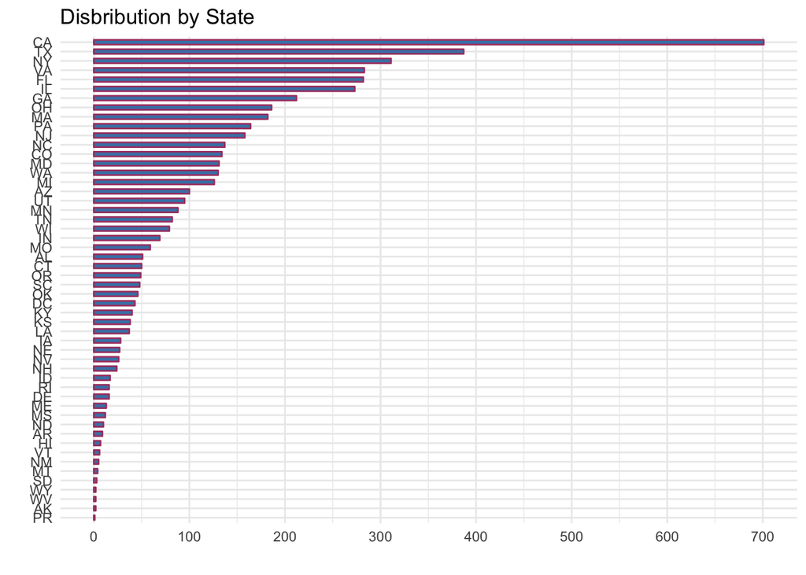

```r
# Answer Question 1 here

## distribution of companies in the dataset by State
companies_byState <- inc %>% group_by(State) %>% summarise(n=n()) %>% arrange(desc(n))

plt1 <-
  ggplot(data = companies_byState[1:52,], aes(x=reorder(State,n), y=n)) +
  geom_bar(stat="identity", width=0.5, color="#AA4371", fill="steelblue",
           position=position_dodge()) +
    #geom_text(aes(label=round(n, digits=2)), hjust=1.3, size=3.0, color="white") +
    coord_flip() +
    scale_y_continuous(breaks=seq(0,700,100)) +
    ggtitle("Disbribution by State") +
    xlab("") + ylab("") +
    theme_minimal()

## Plotting the graph

plt1
```

## Quesiton 2

Lets dig in on the state with the 3rd most companies in the data set. Imagine you work for the state and are interested in how many people are employed by companies in different industries. Create a plot that shows the average and/or median employment by industry for companies in this state (only use cases with full data, use R’s `complete.cases()` function.) In addition to this, your graph should show how variable the ranges are, and you should deal with outliers.

```r
# Answer Question 2 here

## state with the 3rd most companies in the data set

kable(inc %>% group_by(State) %>% summarise(n=n()) %>% arrange(desc(n)) %>% top_n(3)) %>% kable_styling()
```

| State | n |
| --- | --- |
| CA | 701 |
| TX | 387 |
| NY | 311 |

As shown ablove, the state with third most companies in the dataset is New York.

Let’s evaluate the company cases:

```r
company_cases <- inc[complete.cases(inc),]
```

Now, let’s find the median number of employees in each industry for NY state.

```r
kable(company_cases%>%filter(State=='NY')%>%group_by(Industry)%>%summarise(min=min(Employees),median=median(Employees),max=max(Employees),var=var(Employees)) %>% arrange(desc(var))) %>% kable_styling()
```

| Industry | min | median | max | var |
| --- | --- | --- | --- | --- |
| Business Products & Services | 4 | 70.5 | 32000 | 3.894641e+07 |
| Consumer Products & Services | 5 | 25.0 | 10000 | 5.835802e+06 |
| Travel & Hospitality | 6 | 61.0 | 2280 | 6.974669e+05 |
| Human Resources | 7 | 56.0 | 2081 | 4.634787e+05 |
| IT Services | 8 | 54.0 | 3000 | 2.241769e+05 |
| Software | 15 | 80.0 | 1271 | 1.404907e+05 |
| Security | 25 | 32.5 | 450 | 4.415000e+04 |
| Media | 4 | 45.0 | 602 | 3.099560e+04 |
| Financial Services | 14 | 81.0 | 483 | 2.299190e+04 |
| Environmental Services | 60 | 155.0 | 250 | 1.805000e+04 |
| Food & Beverage | 5 | 41.0 | 383 | 1.390028e+04 |
| Energy | 5 | 120.0 | 294 | 1.106670e+04 |
| Telecommunications | 6 | 31.0 | 316 | 1.064462e+04 |
| Manufacturing | 11 | 30.0 | 307 | 8.048231e+03 |
| Health | 2 | 45.0 | 298 | 7.505141e+03 |
| Construction | 10 | 24.5 | 219 | 6.392000e+03 |
| Advertising & Marketing | 2 | 38.0 | 270 | 3.872536e+03 |
| Education | 19 | 50.5 | 200 | 2.359516e+03 |
| Engineering | 11 | 54.5 | 94 | 1.583000e+03 |
| Logistics & Transportation | 1 | 23.5 | 70 | 8.430000e+02 |
| Retail | 3 | 13.5 | 75 | 6.378736e+02 |
| Insurance | 15 | 32.5 | 50 | 6.125000e+02 |
| Real Estate | 7 | 18.0 | 30 | 9.425000e+01 |
| Computer Hardware | 44 | 44.0 | 44 | NA |
| Government Services | 17 | 17.0 | 17 | NA |

The data above shows the min, median, and max number of employees for each industry in NY. It is ordered from highest to lowest variability.

In order to show the median number of employees, a box plot could be plotted.The plot will also display range of data and outliers. Number of distinct industries are 25. Let’s use the table above to show that companies that have higher variability in employee number is ones with higher maximum number of employees.

Below, the industries are grouped together.

```r
Business_Products_Services <- c('Business Products & Services')
Consumer_Products_Services <- c('Consumer Products & Services')
group_2 <- c('Travel & Hospitality', 'Human Resources', 'IT Services', 'Software')
group_3 <- c('Security', 'Media', 'Financial Services',  'Environmental Services', 'Food & Beverage')
group_4 <- c('Energy', 'Telecommunications', 'Manufacturing', 'Health', 'Construction')
group_5 <- c('Advertising & Marketing', 'Education', 'Engineering', 'Logistics & Transportation', 'Retail')
group_6 <- c('Insurance', 'Real Estate', 'Computer Hardware', 'Government Services')
```

Creating box plots for the respective groups:

```r
plt_Business_Products_Services <- ggplot(company_cases %>% filter(State=='NY' & Industry %in% Business_Products_Services), aes(x = Industry, y = Employees)) +
        coord_flip() +
        geom_boxplot(outlier.colour="red", outlier.shape=8,
             outlier.size=1, notch=FALSE)

plt_Consumer_Products_Services <- ggplot(company_cases %>% filter(State=='NY' & Industry %in% Consumer_Products_Services), aes(x = Industry, y = Employees)) +
        coord_flip() +
        geom_boxplot(outlier.colour="red", outlier.shape=8,
             outlier.size=1, notch=FALSE)

plt_group_2 <- ggplot(company_cases %>% filter(State=='NY' & Industry %in% group_2), aes(x = Industry, y = Employees)) +
        coord_flip() +
        geom_boxplot(outlier.colour="red", outlier.shape=8,
             outlier.size=1, notch=FALSE)

plt_group_3 <- ggplot(company_cases %>% filter(State=='NY' & Industry %in% group_3), aes(x = Industry, y = Employees)) +
        coord_flip() +
        geom_boxplot(outlier.colour="red", outlier.shape=8,
             outlier.size=1, notch=FALSE)

plt_group_4 <- ggplot(company_cases %>% filter(State=='NY' & Industry %in% group_4), aes(x = Industry, y = Employees)) +
        coord_flip() +
        geom_boxplot(outlier.colour="red", outlier.shape=8,
             outlier.size=1, notch=FALSE)

plt_group_5 <- ggplot(company_cases %>% filter(State=='NY' & Industry %in% group_5), aes(x = Industry, y = Employees)) +
        coord_flip() +
        geom_boxplot(outlier.colour="red", outlier.shape=8,
             outlier.size=1, notch=FALSE)

plt_group_6 <- ggplot(company_cases %>% filter(State=='NY' & Industry %in% group_6), aes(x = Industry, y = Employees)) +
        coord_flip() +
        geom_boxplot(outlier.colour="red", outlier.shape=8,
             outlier.size=1, notch=FALSE)
```

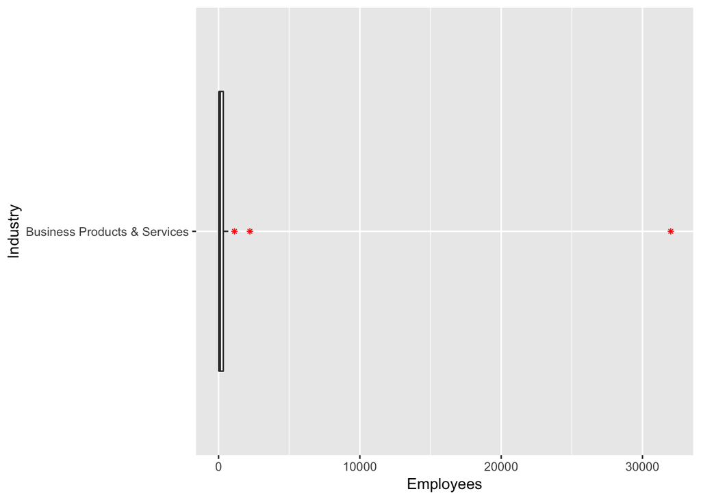

```r
plt_Business_Products_Services
```

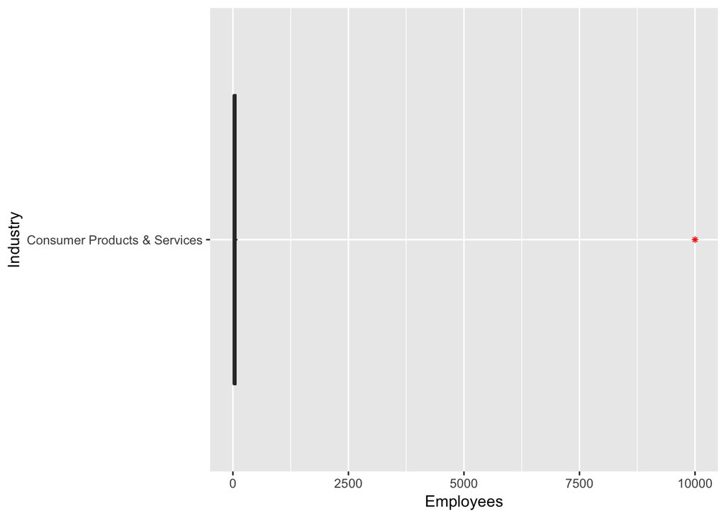

```r
plt_Consumer_Products_Services
```

Box plots for remaining industries: x-axis scale for each group is different.

The box plots for ‘Business Products & Services’ and ‘Consumer Products & Services’ came out as very small. The outlier data is causing the box plot of these 2 industries to flatten out.

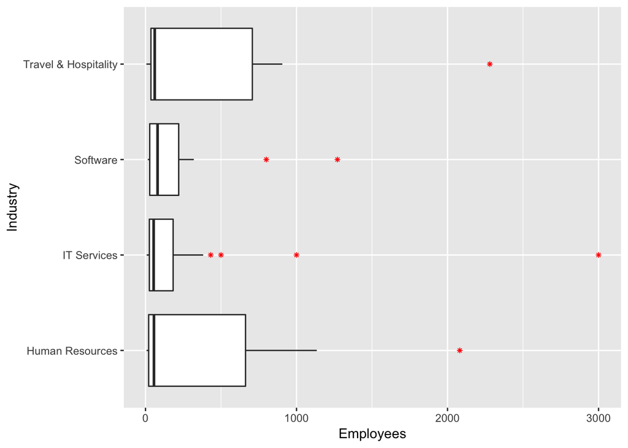

```r
plt_group_2
```

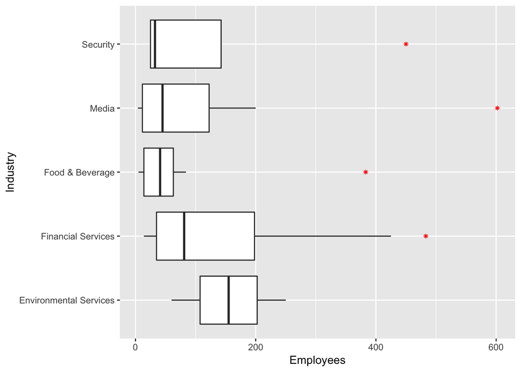

```r
plt_group_3
```

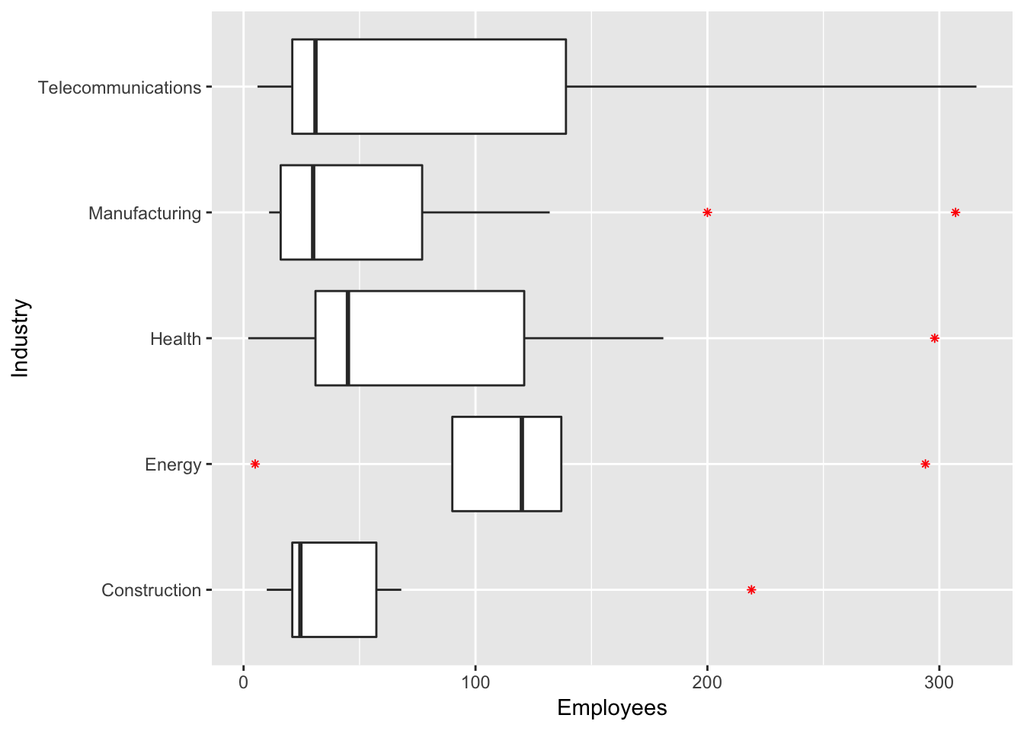

```r
plt_group_4
```

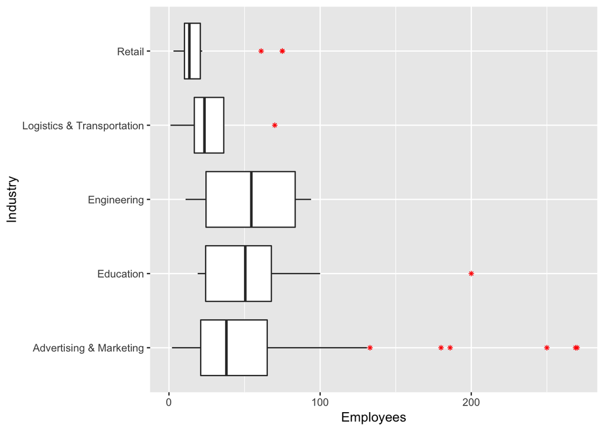

```r
plt_group_5
```

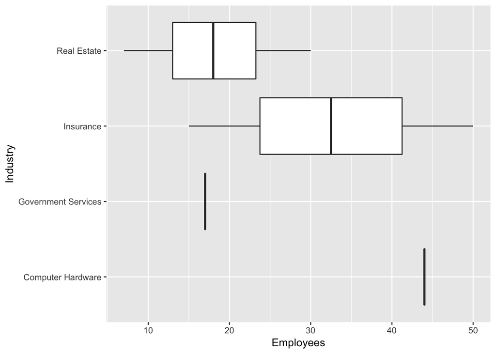

```r
plt_group_6
```

## Question 3

Now imagine you work for an investor and want to see which industries generate the most revenue per employee. Create a chart that makes this information clear. Once again, the distribution per industry should be shown.

```r
# Answer Question 3 here

revenue_perEmployee <-
company_cases %>% group_by(Industry) %>% summarise(count=n(), total_revenue=sum(Revenue), total_employees=sum(Employees), revenue_perEmployee=total_revenue/total_employees) %>% arrange(desc(revenue_perEmployee))

kable(revenue_perEmployee) %>% kable_styling()
```

| Industry | count | total_revenue | total_employees | revenue_perEmployee |
| --- | --- | --- | --- | --- |
| Computer Hardware | 44 | 11885700000 | 9714 | 1223563.93 |
| Energy | 109 | 13771600000 | 26437 | 520921.44 |
| Construction | 187 | 13174300000 | 29099 | 452740.64 |
| Logistics & Transportation | 154 | 14837800000 | 39994 | 371000.65 |
| Consumer Products & Services | 203 | 14956400000 | 45464 | 328972.37 |
| Insurance | 50 | 2337900000 | 7339 | 318558.39 |
| Manufacturing | 255 | 12603600000 | 43942 | 286823.54 |
| Retail | 203 | 10257400000 | 37068 | 276718.46 |
| Financial Services | 260 | 13150900000 | 47693 | 275740.67 |
| Environmental Services | 51 | 2638800000 | 10155 | 259852.29 |
| Telecommunications | 127 | 7287900000 | 30842 | 236297.91 |
| Government Services | 202 | 6009100000 | 26185 | 229486.35 |
| Business Products & Services | 480 | 26345900000 | 117357 | 224493.64 |
| Health | 354 | 17860100000 | 82430 | 216669.90 |
| IT Services | 732 | 20525000000 | 102788 | 199682.84 |
| Advertising & Marketing | 471 | 7785000000 | 39731 | 195942.71 |
| Food & Beverage | 129 | 12812500000 | 65911 | 194390.92 |
| Media | 54 | 1742400000 | 9532 | 182794.80 |
| Software | 341 | 8134600000 | 51262 | 158686.75 |
| Real Estate | 95 | 2956800000 | 18893 | 156502.41 |
| Education | 83 | 1139300000 | 7685 | 148249.84 |
| Travel & Hospitality | 62 | 2931600000 | 23035 | 127267.20 |
| Engineering | 74 | 2532500000 | 20435 | 123929.53 |
| Security | 73 | 3812800000 | 41059 | 92861.49 |
| Human Resources | 196 | 9246100000 | 226980 | 40735.31 |

The code below plots the revenue per employee as a bar chart sorted by revenue per employee from highest to lowest.

A second bar chart plot is generated that shows the distribution of companies by industry sorted by revenue per employee from highest to lowest (same order as the first plot).

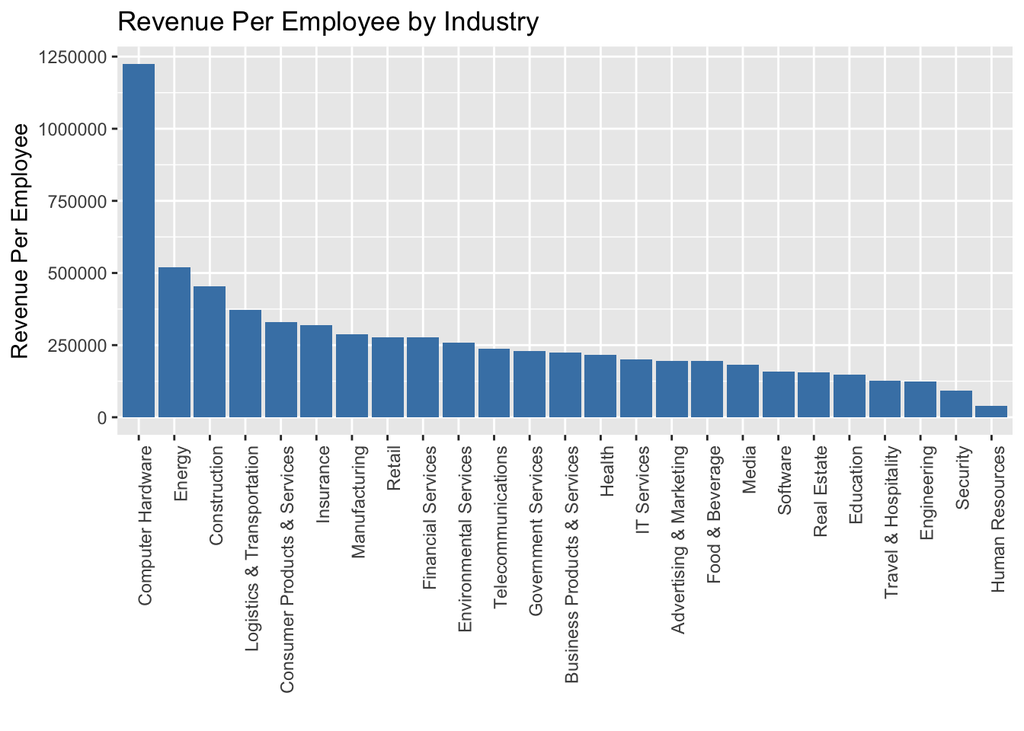

```r
plt_revenue_perEmployee_a<- ggplot(data=revenue_perEmployee, aes(x=reorder(Industry,-revenue_perEmployee), y=revenue_perEmployee)) +
     geom_bar(stat="identity", fill="steelblue") +
     theme(axis.text.x = element_text(angle = 90, hjust = 1)) +
     ggtitle("Revenue Per Employee by Industry") +
     ylab("Revenue Per Employee") +
     xlab("")

plt_revenue_perEmployee_b <- ggplot(data=revenue_perEmployee, aes(x=reorder(Industry,-revenue_perEmployee), y=count)) +
     geom_bar(stat="identity", fill="steelblue") +
     theme(axis.text.x = element_text(angle = 90, hjust = 1)) +
     ggtitle("Distribution of Companies by Industry") +
     ylab("Revenue Per Employee") +
     xlab("")

plt_revenue_perEmployee_a
```

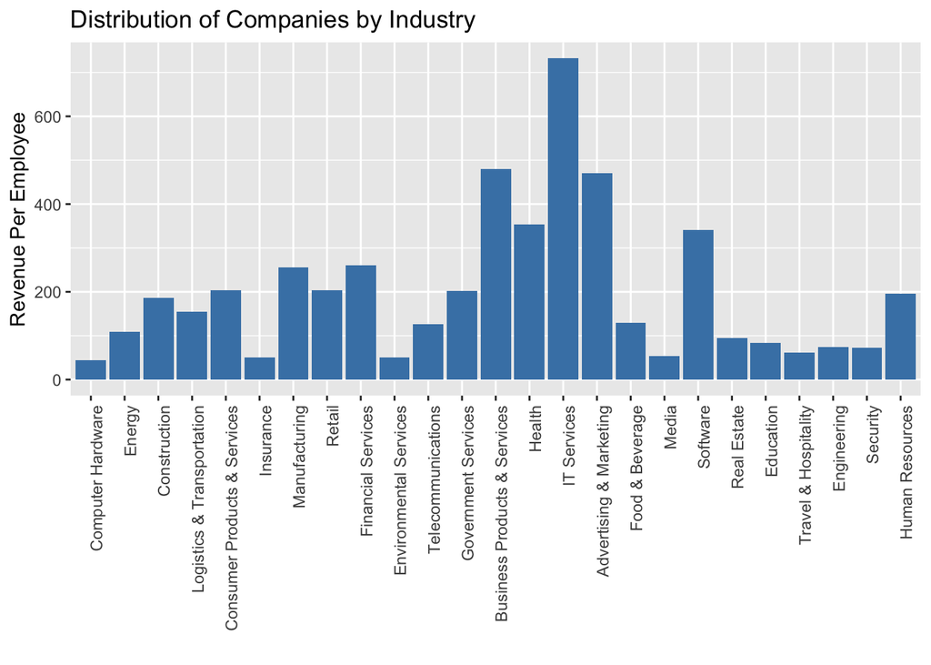

```r
plt_revenue_perEmployee_b
```